# nyc_flight_data

Marco Camalich

2023-09-06

```r
library(nycflights13)
library(tidyverse)
library(janitor)
library(here)
```

```r
flights
```

| year | month | day | dep_time | sched_dep_time | dep_delay | arr_time | sched_arr_time | arr_delay | carrier | flight | tailnum | origin | dest | air_time | distance | hour | minute | time_hour |
| --- | --- | --- | --- | --- | --- | --- | --- | --- | --- | --- | --- | --- | --- | --- | --- | --- | --- | --- |
| 2013 | 1 | 1 | 517 | 515 | 2 | 830 | 819 | 11 | UA | 1545 | N14228 | EWR | IAH | 227 | 1400 | 5 | 15 | 2013-01-01 05:00:00 |
| 2013 | 1 | 1 | 533 | 529 | 4 | 850 | 830 | 20 | UA | 1714 | N24211 | LGA | IAH | 227 | 1416 | 5 | 29 | 2013-01-01 05:00:00 |
| 2013 | 1 | 1 | 542 | 540 | 2 | 923 | 850 | 33 | AA | 1141 | N619AA | JFK | MIA | 160 | 1089 | 5 | 40 | 2013-01-01 05:00:00 |
| 2013 | 1 | 1 | 544 | 545 | -1 | 1004 | 1022 | -18 | B6 | 725 | N804JB | JFK | BQN | 183 | 1576 | 5 | 45 | 2013-01-01 05:00:00 |
| 2013 | 1 | 1 | 554 | 600 | -6 | 812 | 837 | -25 | DL | 461 | N668DN | LGA | ATL | 116 | 762 | 6 | 0 | 2013-01-01 06:00:00 |
| 2013 | 1 | 1 | 554 | 558 | -4 | 740 | 728 | 12 | UA | 1696 | N39463 | EWR | ORD | 150 | 719 | 5 | 58 | 2013-01-01 05:00:00 |
| 2013 | 1 | 1 | 555 | 600 | -5 | 913 | 854 | 19 | B6 | 507 | N516JB | EWR | FLL | 158 | 1065 | 6 | 0 | 2013-01-01 06:00:00 |
| 2013 | 1 | 1 | 557 | 600 | -3 | 709 | 723 | -14 | EV | 5708 | N829AS | LGA | IAD | 53 | 229 | 6 | 0 | 2013-01-01 06:00:00 |
| 2013 | 1 | 1 | 557 | 600 | -3 | 838 | 846 | -8 | B6 | 79 | N593JB | JFK | MCO | 140 | 944 | 6 | 0 | 2013-01-01 06:00:00 |
| 2013 | 1 | 1 | 558 | 600 | -2 | 753 | 745 | 8 | AA | 301 | N3ALAA | LGA | ORD | 138 | 733 | 6 | 0 | 2013-01-01 06:00:00 |

[output cut: 990 more lines]

```r
glimpse(flights)
```

```
Rows: 336,776
Columns: 19
$ year           <int> 2013, 2013, 2013, 2013, 2013, 2013, 2013, 2013, 2013, 2013,…
$ month          <int> 1, 1, 1, 1, 1, 1, 1, 1, 1, 1, 1, 1, 1, 1, 1, 1, 1, 1, 1, 1,…
$ day            <int> 1, 1, 1, 1, 1, 1, 1, 1, 1, 1, 1, 1, 1, 1, 1, 1, 1, 1, 1, 1,…
$ dep_time       <int> 517, 533, 542, 544, 554, 554, 555, 557, 557, 558, 558, 558,…
$ sched_dep_time <int> 515, 529, 540, 545, 600, 558, 600, 600, 600, 600, 600, 600,…
$ dep_delay      <dbl> 2, 4, 2, -1, -6, -4, -5, -3, -3, -2, -2, -2, -2, -2, -1, 0,…
$ arr_time       <int> 830, 850, 923, 1004, 812, 740, 913, 709, 838, 753, 849, 853…
$ sched_arr_time <int> 819, 830, 850, 1022, 837, 728, 854, 723, 846, 745, 851, 856…
$ arr_delay      <dbl> 11, 20, 33, -18, -25, 12, 19, -14, -8, 8, -2, -3, 7, -14, 3…
$ carrier        <chr> "UA", "UA", "AA", "B6", "DL", "UA", "B6", "EV", "B6", "AA",…
$ flight         <int> 1545, 1714, 1141, 725, 461, 1696, 507, 5708, 79, 301, 49, 7…
$ tailnum        <chr> "N14228", "N24211", "N619AA", "N804JB", "N668DN", "N39463",…
$ origin         <chr> "EWR", "LGA", "JFK", "JFK", "LGA", "EWR", "EWR", "LGA", "JF…
$ dest           <chr> "IAH", "IAH", "MIA", "BQN", "ATL", "ORD", "FLL", "IAD", "MC…
$ air_time       <dbl> 227, 227, 160, 183, 116, 150, 158, 53, 140, 138, 149, 158, …
$ distance       <dbl> 1400, 1416, 1089, 1576, 762, 719, 1065, 229, 944, 733, 1028…
$ hour           <dbl> 5, 5, 5, 5, 6, 5, 6, 6, 6, 6, 6, 6, 6, 6, 6, 5, 6, 6, 6, 6,…
$ minute         <dbl> 15, 29, 40, 45, 0, 58, 0, 0, 0, 0, 0, 0, 0, 0, 0, 59, 0, 0,…
$ time_hour      <dttm> 2013-01-01 05:00:00, 2013-01-01 05:00:00, 2013-01-01 05:00…
```

```r
head(flights)
```

| year | month | day | dep_time | sched_dep_time | dep_delay | arr_time | sched_arr_time | arr_delay | carrier | flight | tailnum | origin | dest | air_time | distance | hour | minute | time_hour |
| --- | --- | --- | --- | --- | --- | --- | --- | --- | --- | --- | --- | --- | --- | --- | --- | --- | --- | --- |
| 2013 | 1 | 1 | 517 | 515 | 2 | 830 | 819 | 11 | UA | 1545 | N14228 | EWR | IAH | 227 | 1400 | 5 | 15 | 2013-01-01 05:00:00 |
| 2013 | 1 | 1 | 533 | 529 | 4 | 850 | 830 | 20 | UA | 1714 | N24211 | LGA | IAH | 227 | 1416 | 5 | 29 | 2013-01-01 05:00:00 |
| 2013 | 1 | 1 | 542 | 540 | 2 | 923 | 850 | 33 | AA | 1141 | N619AA | JFK | MIA | 160 | 1089 | 5 | 40 | 2013-01-01 05:00:00 |
| 2013 | 1 | 1 | 544 | 545 | -1 | 1004 | 1022 | -18 | B6 | 725 | N804JB | JFK | BQN | 183 | 1576 | 5 | 45 | 2013-01-01 05:00:00 |
| 2013 | 1 | 1 | 554 | 600 | -6 | 812 | 837 | -25 | DL | 461 | N668DN | LGA | ATL | 116 | 762 | 6 | 0 | 2013-01-01 06:00:00 |
| 2013 | 1 | 1 | 554 | 558 | -4 | 740 | 728 | 12 | UA | 1696 | N39463 | EWR | ORD | 150 | 719 | 5 | 58 | 2013-01-01 05:00:00 |

```r
df1=flights
df2=df1 |>
  filter(month == 9, origin == "MIA")
df3=df1 |>
  filter(month == 9, dest == "MIA")
df4=df1 |>
  filter(month == 1, dest == "MIA")
df5=df1 |>
  filter(month >= 6 & month <= 8, dest == "ORD" | dest == "MDW")
```

For flights to MIAMI in September, find the unique flight numbers.

```r
df3_unique=df3[!duplicated(df3$flight), ]
df3_unique$flight
```

```
 [1]  701 1895 1921 1165 1713 1938  647 1813  874 1153 1623 2093 2041 1401 1621  825
[17] 1775 1373 1559 1982 1999  613 1611   83 1512 1709 2003 2190  446 2098 1515 2139
[33] 2243 1175 1205 1345 2279 2267 1499 1599 1256 1697  476 1073  145 2297  172 1410
[49] 2351 2437 1158 1160 1186 1680  577 1732 1182
```

Create a dataframe df6 composed of flights to Miami with a flight number matching the smallest flight number from the set above.

```r
df6 = df3 |> filter(flight==min(df3$flight))
head(df6)
```

| year | month | day | dep_time | sched_dep_time | dep_delay | arr_time | sched_arr_time | arr_delay | carrier | flight | tailnum | origin | dest | air_time | distance | hour | minute | time_hour |
| --- | --- | --- | --- | --- | --- | --- | --- | --- | --- | --- | --- | --- | --- | --- | --- | --- | --- | --- |
| 2013 | 9 | 1 | 1839 | 1810 | 29 | 2145 | 2119 | 26 | DL | 83 | N319US | JFK | MIA | 144 | 1089 | 18 | 10 | 2013-09-01 18:00:00 |
| 2013 | 9 | 2 | 2152 | 1810 | 222 | 122 | 2128 | 234 | DL | 83 | N310NW | JFK | MIA | 142 | 1089 | 18 | 10 | 2013-09-02 18:00:00 |
| 2013 | 9 | 3 | 1814 | 1820 | -6 | 2115 | 2145 | -30 | DL | 83 | N936DL | JFK | MIA | 155 | 1089 | 18 | 20 | 2013-09-03 18:00:00 |
| 2013 | 9 | 4 | 1813 | 1820 | -7 | 2106 | 2145 | -39 | DL | 83 | N970DL | JFK | MIA | 146 | 1089 | 18 | 20 | 2013-09-04 18:00:00 |
| 2013 | 9 | 5 | 1815 | 1820 | -5 | 2058 | 2145 | -47 | DL | 83 | N928DL | JFK | MIA | 138 | 1089 | 18 | 20 | 2013-09-05 18:00:00 |
| 2013 | 9 | 6 | 1911 | 1820 | 51 | 2212 | 2145 | 27 | DL | 83 | N930DL | JFK | MIA | 142 | 1089 | 18 | 20 | 2013-09-06 18:00:00 |

Create a visualization (using ggplot) to show the DELAYS associated with this flight number.

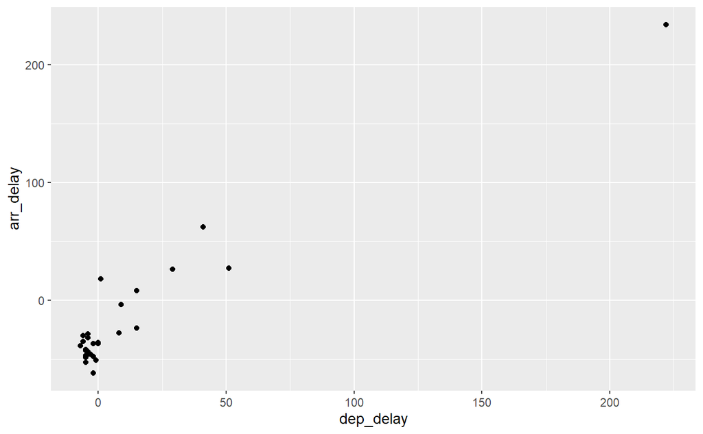

```r
ggplot(data=df6, mapping=aes(x=dep_delay, y=arr_delay)) + geom_point()
```

Create ANOTHER visualization that helps to understand the relationship between the arrival delay and the departure delay. Try to find something interesting to say.

**A scatter plot is an effective tool for contrasting the relationship between arrival delay and departure delay for several reasons. Firstly, it represents individual data points which display each pair of data as a point on the graph, enabling a clear view of data distribution and dispersion. Additionally, it aids in identifying visual patterns, such as the general trend of points clustering in a specific direction as well as detection of correlations. Also, scatter plots facilitate the detection of outliers, which reveal exceptional situations in the flights. The dots observable in the graph below lllustrate the correlation between the rows, and allow decision makers to get a quick and easy visual comparison between variables, making trends and discrepancies easily identifiable.**

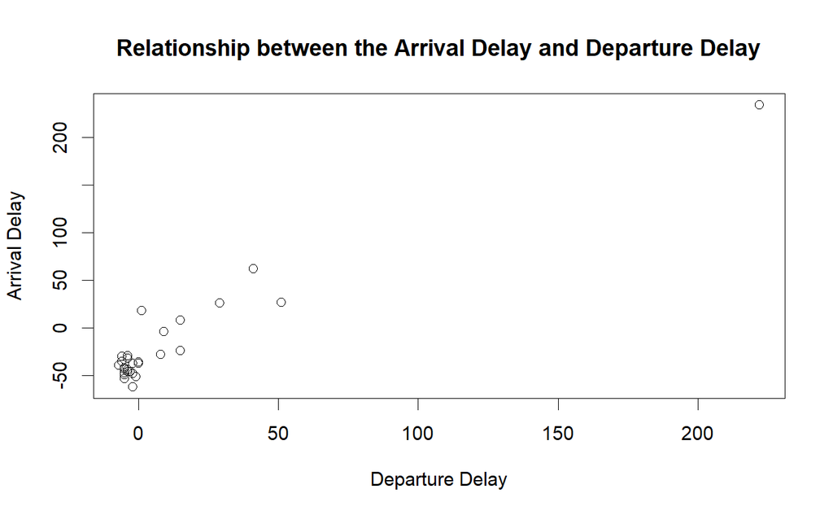

```r
plot(df6$dep_delay, df6$arr_delay,
     xlab = "Departure Delay",
     ylab = "Arrival Delay",
     main = "Relationship between the Arrival Delay and Departure Delay")
```

```r
df7=df1 |> filter(dest=="MIA", origin=="LGA") |> mutate(flt_delta=arr_delay-dep_delay)
```

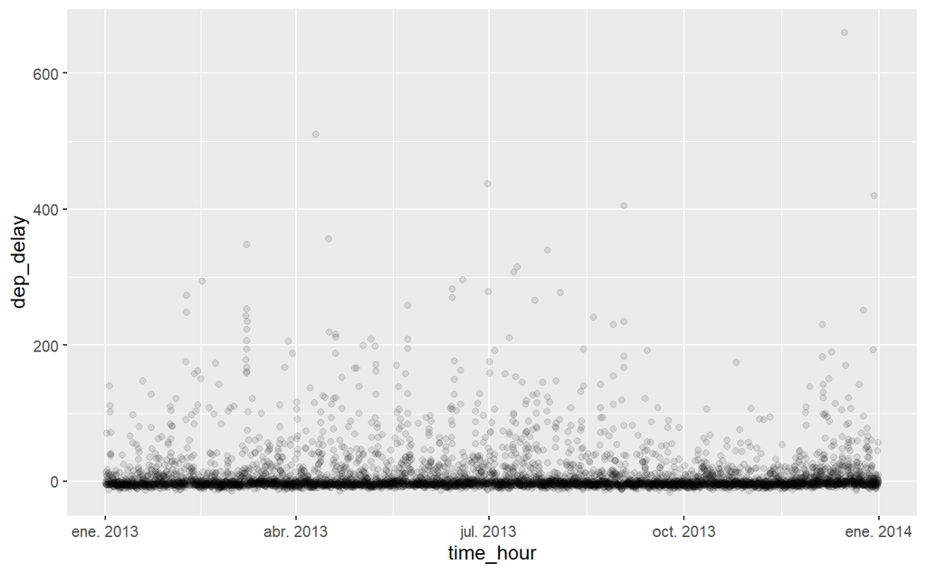

```r
df7 |> ggplot(aes(x=time_hour,y=dep_delay)) + geom_point(alpha=.1)
```

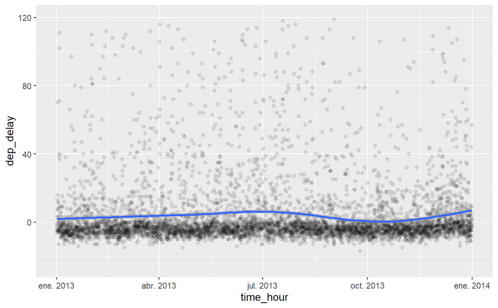

```r
df7 |> ggplot(aes(x=time_hour,y=dep_delay)) + geom_point(alpha=.1)+stat_smooth()+ylim(-25,120)
```

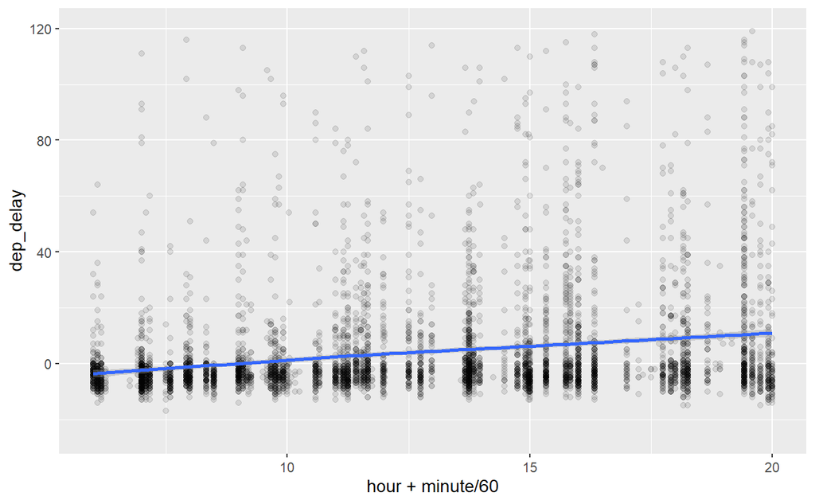

```r
df7 |> ggplot(aes(x=hour+minute/60,y=dep_delay)) + geom_point(alpha=.1)+stat_smooth()+ylim(-25,120)
```

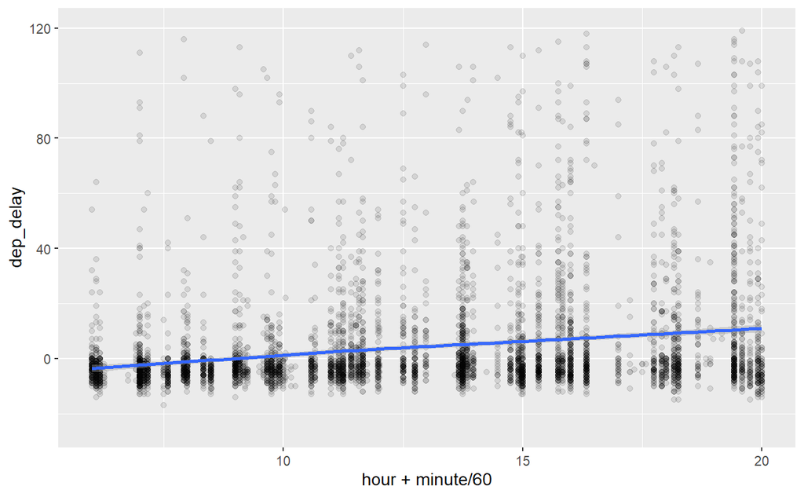

```r
df7 |>
mutate(day_of_week=weekdays(time_hour)) |> ggplot(aes(x=hour+minute/60,y=dep_delay,color(day_of_week))) + geom_point(alpha=.1)+
stat_smooth()+
ylim(-25,120)
```